# Activity Recognition of Weight Lifting Exercises

## Background

Using devices such as Jawbone Up, Nike FuelBand, and Fitbit it is now possible to collect a large amount of data about personal activity relatively inexpensively. These type of devices are part of the quantified self movement – a group of enthusiasts who take measurements about themselves regularly to improve their health, to find patterns in their behavior, or because they are tech geeks. One thing that people regularly do is quantify how much of a particular activity they do, but they rarely quantify how well they do it. In this project, data from accelerometers on the belt, forearm, arm, and dumbell of 6 participants are used. They were asked to perform barbell lifts correctly and incorrectly in 5 different ways what makes 5 classes in the dataset:  
Class A - exactly according to the specification  
Class B - throwing the elbows to the front  
Class C - lifting the dumbbell only halfway  
Class D - lowering the dumbbell only halfway  
Class E - throwing the hips to the front

More information is available from the website here: http://groupware.les.inf.puc-rio.br/har (see the section on the Weight Lifting Exercise Dataset).

## Reading data

The training data for this project are available here: https://d396qusza40orc.cloudfront.net/predmachlearn/pml-training.csv

20 observations to predict the outcome variable (classe) are available here: https://d396qusza40orc.cloudfront.net/predmachlearn/pml-testing.csv

```r
readData <- read.csv("pml-training.csv", header=T)
readNew <- read.csv("pml-testing.csv", header=T)
```

## Data cleaning and preparation

Training dataset consists of 160 variables and 19622 observations. **Classe** is considered as an outcome variable.

```r
dim(readData)
```

```
## [1] 19622   160
```

We can do some exloration using str() and summary(). We can see that first seven variables are not necessary in the analysis, because they refer to users’ names and excercise timestamps. They will be removed from the further analysis.

```r
str(readData)
summary(readData)
wled <- readData[,-c(1:7)]
```

There are 34 factor variables in the dataset, remaining variables are integer or numeric. For the needs of the project all factor variables except outcome (classe) will be turned into numeric variables.

```r
table(sapply(wled[1,], class))
```

```
##
##  factor integer numeric
##      34      31      88
```

```r
for (i in 1:ncol(wled)-1) {
    if (class(wled[,i])=="factor") {
        wled[,i] <- as.numeric(levels(wled[,i]))[wled[,i]]
    }
}

table(sapply(wled[1,], class))
```

```
##
##  factor integer numeric
##       1      31     121
```

Summary showed that many variables values are mainly NA. They should not be included in the model because it could bias its accuracy. After this operation 52 predictors left in the dataset.

```r
missing <- is.na(wled)
delete <- which(colSums(missing) > 19000)
data <- wled[, -delete]
dim(data)
```

```
## [1] 19622    53
```

Next, variables variability was checked. Predictors with no or small variability have little predicton value so they should not be taken into account while building the model. NearZeroVar function results indicate that all of predictors have enough variability to be kept in the dataset (FALSE nzv value).

```r
library(caret)
nearZeroVar(data,saveMetrics=TRUE)
```

```
##                      freqRatio percentUnique zeroVar   nzv
## roll_belt             1.101904     6.7781062   FALSE FALSE
## pitch_belt            1.036082     9.3772296   FALSE FALSE
## yaw_belt              1.058480     9.9734991   FALSE FALSE
## total_accel_belt      1.063160     0.1477933   FALSE FALSE
## gyros_belt_x          1.058651     0.7134849   FALSE FALSE
## gyros_belt_y          1.144000     0.3516461   FALSE FALSE
## gyros_belt_z          1.066214     0.8612782   FALSE FALSE
## accel_belt_x          1.055412     0.8357966   FALSE FALSE
## accel_belt_y          1.113725     0.7287738   FALSE FALSE
## accel_belt_z          1.078767     1.5237998   FALSE FALSE
## magnet_belt_x         1.090141     1.6664968   FALSE FALSE
## magnet_belt_y         1.099688     1.5187035   FALSE FALSE
## magnet_belt_z         1.006369     2.3290184   FALSE FALSE
## roll_arm             52.338462    13.5256345   FALSE FALSE
## pitch_arm            87.256410    15.7323412   FALSE FALSE
## yaw_arm              33.029126    14.6570176   FALSE FALSE
## total_accel_arm       1.024526     0.3363572   FALSE FALSE
## gyros_arm_x           1.015504     3.2769341   FALSE FALSE
## gyros_arm_y           1.454369     1.9162165   FALSE FALSE
## gyros_arm_z           1.110687     1.2638875   FALSE FALSE
## accel_arm_x           1.017341     3.9598410   FALSE FALSE
## accel_arm_y           1.140187     2.7367241   FALSE FALSE
## accel_arm_z           1.128000     4.0362858   FALSE FALSE
## magnet_arm_x          1.000000     6.8239731   FALSE FALSE
## magnet_arm_y          1.056818     4.4439914   FALSE FALSE
## magnet_arm_z          1.036364     6.4468454   FALSE FALSE
## roll_dumbbell         1.022388    84.2065029   FALSE FALSE
## pitch_dumbbell        2.277372    81.7449801   FALSE FALSE
## yaw_dumbbell          1.132231    83.4828254   FALSE FALSE
## total_accel_dumbbell  1.072634     0.2191418   FALSE FALSE
## gyros_dumbbell_x      1.003268     1.2282132   FALSE FALSE
## gyros_dumbbell_y      1.264957     1.4167771   FALSE FALSE
## gyros_dumbbell_z      1.060100     1.0498420   FALSE FALSE
## accel_dumbbell_x      1.018018     2.1659362   FALSE FALSE
## accel_dumbbell_y      1.053061     2.3748853   FALSE FALSE
## accel_dumbbell_z      1.133333     2.0894914   FALSE FALSE
## magnet_dumbbell_x     1.098266     5.7486495   FALSE FALSE
## magnet_dumbbell_y     1.197740     4.3012945   FALSE FALSE
## magnet_dumbbell_z     1.020833     3.4451126   FALSE FALSE
## roll_forearm         11.589286    11.0895933   FALSE FALSE
## pitch_forearm        65.983051    14.8557741   FALSE FALSE
## yaw_forearm          15.322835    10.1467740   FALSE FALSE
## total_accel_forearm   1.128928     0.3567424   FALSE FALSE
## gyros_forearm_x       1.059273     1.5187035   FALSE FALSE
## gyros_forearm_y       1.036554     3.7763735   FALSE FALSE
## gyros_forearm_z       1.122917     1.5645704   FALSE FALSE
## accel_forearm_x       1.126437     4.0464784   FALSE FALSE
## accel_forearm_y       1.059406     5.1116094   FALSE FALSE
## accel_forearm_z       1.006250     2.9558659   FALSE FALSE
## magnet_forearm_x      1.012346     7.7667924   FALSE FALSE
## magnet_forearm_y      1.246914     9.5403119   FALSE FALSE
## magnet_forearm_z      1.000000     8.5771073   FALSE FALSE
## classe                1.469581     0.0254816   FALSE FALSE
```

We split our data into a training dataset (70% of cases) and a testing dataset (30% of cases).

```r
set.seed(1224)
inTrain <- createDataPartition(y=data$classe, p=0.7, list=FALSE)

training <- data[inTrain,]
dim(training)
```

```
## [1] 13737    53
```

```r
testing <- data[-inTrain,]
dim(testing)
```

```
## [1] 5885   53
```

Charts below present the frequency of **classe** variable levels in trainng and testing datasets. Distrubutions in both datasets are very similar and they are rather balanced, with some advantage of classe A frequency.

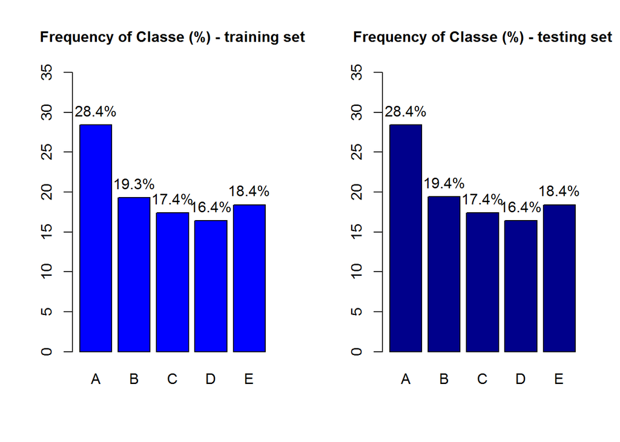

```r
traincounts <- round(prop.table(table(training$classe)),3)*100
testcounts <- round(prop.table(table(testing$classe)),3)*100

par(mfrow=c(1,2))
b1 <- barplot(traincounts, main="Frequency of Classe (%) - training set", cex.main=1, ylim=c(0,35),col="blue")
text(b1, traincounts, labels=paste(traincounts,"%",sep=""), pos=3, cex=1)
b2 <- barplot(testcounts, main="Frequency of Classe (%) - testing set", cex.main=1, ylim=c(0,35),col="darkblue")
text(b2, testcounts, labels=paste(testcounts,"%",sep=""), pos=3, cex=1)
```

## Prediction algorithms

To build a prediction model, we will try two algorithms: decision tree and random forest, using *caret* library. We will train each model using **k-fold cross-validation**, with **k=5**. This way each model will be built and validated 5 times with different sub-training and sub-testing datasets, and it will allow to estimate more reliable out-of-sample error.

### Decision tree

The first attempt was building the model with a decision tree.

```r
set.seed(222)
tree <- train(classe ~ ., data=training, method="rpart", trControl=trainControl(method = "cv",number = 5))
tree
```

```
## CART
##
## 13737 samples
##    52 predictor
##     5 classes: 'A', 'B', 'C', 'D', 'E'
##
## No pre-processing
## Resampling: Cross-Validated (5 fold)
## Summary of sample sizes: 10990, 10989, 10990, 10990, 10989
## Resampling results across tuning parameters:
##
##   cp          Accuracy   Kappa       Accuracy SD  Kappa SD
##   0.02644695  0.5797499  0.46831898  0.01731381   0.01759329
##   0.04146069  0.4830719  0.32759625  0.07146561   0.12305074
##   0.11280643  0.3147019  0.04654906  0.04157791   0.06377367
##
## Accuracy was used to select the optimal model using  the largest value.
## The final value used for the model was cp = 0.02644695.
```

```r
tree$finalModel
```

```
## n= 13737
##
## node), split, n, loss, yval, (yprob)
##       * denotes terminal node
##
##   1) root 13737 9831 A (0.28 0.19 0.17 0.16 0.18)
##     2) roll_belt< 130.5 12608 8712 A (0.31 0.21 0.19 0.18 0.11)
##       4) pitch_forearm< -33.95 1090    7 A (0.99 0.0064 0 0 0) *
##       5) pitch_forearm>=-33.95 11518 8705 A (0.24 0.23 0.21 0.2 0.12)
##        10) yaw_belt>=169.5 595   62 A (0.9 0.044 0 0.052 0.0084) *
##        11) yaw_belt< 169.5 10923 8298 B (0.21 0.24 0.22 0.2 0.13)
##          22) magnet_dumbbell_z< -93.5 1314  542 A (0.59 0.28 0.042 0.062 0.027) *
##          23) magnet_dumbbell_z>=-93.5 9609 7268 C (0.16 0.23 0.24 0.22 0.14)
##            46) pitch_belt< -42.95 563   93 B (0.014 0.83 0.096 0.027 0.028) *
##            47) pitch_belt>=-42.95 9046 6759 C (0.17 0.2 0.25 0.23 0.15)
##              94) magnet_dumbbell_x>=-447.5 3958 2781 B (0.17 0.3 0.098 0.24 0.19)
##               188) roll_belt< 117.5 2423 1379 B (0.16 0.43 0.024 0.13 0.25) *
##               189) roll_belt>=117.5 1535  898 D (0.19 0.087 0.21 0.41 0.094) *
##              95) magnet_dumbbell_x< -447.5 5088 3189 C (0.16 0.12 0.37 0.23 0.12) *
##     3) roll_belt>=130.5 1129   10 E (0.0089 0 0 0 0.99) *
```

However, model accuracy evaluated on testing dataset was only **55.4%**, with out-of-sample error **44.6%**.

```r
predT <- predict(tree, newdata=testing)
confusionMatrix(predT,testing$classe)
```

```
## Confusion Matrix and Statistics
##
##           Reference
## Prediction    A    B    C    D    E
##          A 1005  177   34   39    9
##          B  192  668   42  139  249
##          C  358  240  812  521  253
##          D  115   54  138  265   59
##          E    4    0    0    0  512
##
## Overall Statistics
##
##                Accuracy : 0.5543
##                  95% CI : (0.5415, 0.567)
##     No Information Rate : 0.2845
##     P-Value [Acc > NIR] : < 2.2e-16
##
##                   Kappa : 0.4415
##  Mcnemar's Test P-Value : < 2.2e-16
##
## Statistics by Class:
##
##                      Class: A Class: B Class: C Class: D Class: E
## Sensitivity            0.6004   0.5865   0.7914  0.27490  0.47320
## Specificity            0.9385   0.8689   0.7176  0.92562  0.99917
## Pos Pred Value         0.7951   0.5178   0.3718  0.41997  0.99225
## Neg Pred Value         0.8552   0.8975   0.9422  0.86696  0.89383
## Prevalence             0.2845   0.1935   0.1743  0.16381  0.18386
## Detection Rate         0.1708   0.1135   0.1380  0.04503  0.08700
## Detection Prevalence   0.2148   0.2192   0.3711  0.10722  0.08768
## Balanced Accuracy      0.7694   0.7277   0.7545  0.60026  0.73618
```

### Random forest

Due to low accuracy of decision tree model, ensemble learning method for classification - random forest, was applied to the data. Deafult number of trees (n=500) was used.

```r
set.seed(333)
RFfit <- train(classe ~ .,data=training, method="rf", trControl=trainControl(method = "cv",number = 5,allowParallel = TRUE))
RFfit
```

```
## Random Forest
##
## 13737 samples
##    52 predictor
##     5 classes: 'A', 'B', 'C', 'D', 'E'
##
## No pre-processing
## Resampling: Cross-Validated (5 fold)
## Summary of sample sizes: 10991, 10990, 10990, 10989, 10988
## Resampling results across tuning parameters:
##
##   mtry  Accuracy   Kappa      Accuracy SD  Kappa SD
##    2    0.9909002  0.9884874  0.001237040  0.001566537
##   27    0.9919190  0.9897769  0.002252460  0.002850131
##   52    0.9895893  0.9868297  0.003022653  0.003824318
##
## Accuracy was used to select the optimal model using  the largest value.
## The final value used for the model was mtry = 27.
```

Accuracy verfied on the testing data was **99.4%**, with out-of-sample error **0.6%**. It is much better result than the one obtained with a single decision tree.

```r
predRF <- predict(RFfit, newdata=testing)
confusionMatrix(predRF,testing$classe)
```

```
## Confusion Matrix and Statistics
##
##           Reference
## Prediction    A    B    C    D    E
##          A 1672   11    0    0    0
##          B    0 1125    7    1    1
##          C    1    3 1014    4    0
##          D    0    0    5  958    0
##          E    1    0    0    1 1081
##
## Overall Statistics
##
##                Accuracy : 0.9941
##                  95% CI : (0.9917, 0.9959)
##     No Information Rate : 0.2845
##     P-Value [Acc > NIR] : < 2.2e-16
##
##                   Kappa : 0.9925
##  Mcnemar's Test P-Value : NA
##
## Statistics by Class:
##
##                      Class: A Class: B Class: C Class: D Class: E
## Sensitivity            0.9988   0.9877   0.9883   0.9938   0.9991
## Specificity            0.9974   0.9981   0.9984   0.9990   0.9996
## Pos Pred Value         0.9935   0.9921   0.9922   0.9948   0.9982
## Neg Pred Value         0.9995   0.9971   0.9975   0.9988   0.9998
## Prevalence             0.2845   0.1935   0.1743   0.1638   0.1839
## Detection Rate         0.2841   0.1912   0.1723   0.1628   0.1837
## Detection Prevalence   0.2860   0.1927   0.1737   0.1636   0.1840
## Balanced Accuracy      0.9981   0.9929   0.9933   0.9964   0.9993
```

We can also check, which variables in random forest model have the highest prediction importance.

```r
varImp(RFfit)
```

```
## rf variable importance
##
##   only 20 most important variables shown (out of 52)
##
##                      Overall
## roll_belt             100.00
## pitch_forearm          60.24
## yaw_belt               58.27
## magnet_dumbbell_z      43.84
## magnet_dumbbell_y      43.66
## pitch_belt             43.37
## roll_forearm           40.37
## accel_dumbbell_y       22.49
## magnet_dumbbell_x      19.65
## roll_dumbbell          18.36
## accel_forearm_x        16.67
## magnet_belt_z          15.67
## accel_dumbbell_z       14.79
## total_accel_dumbbell   14.17
## magnet_belt_y          13.96
## magnet_forearm_z       12.76
## accel_belt_z           12.69
## yaw_arm                12.18
## gyros_belt_z           11.22
## magnet_belt_x          10.34
```

## Applying the model to the new observations

We will use the random forest model (as more accurate) to predict the classe of each of 20 observations in pml-testing.csv file. All observations were classified correctly (according to *Course Project Prediction Quiz* result 20/20).

```r
predict(RFfit,readNew)
```

```
##  [1] B A B A A E D B A A B C B A E E A B B B
## Levels: A B C D E
```

## Conclusion

In case of weight lifting exercises data, random forest appeared to be way better predicton algorithm than a single decision tree. Obtained model evaluated on testing dataset had very high accuracy **99.4%**. The most important predictors were: roll belt, pitch forearm and yaw belt.

## References

1. Velloso, E.; Bulling, A.; Gellersen, H.; Ugulino, W.; Fuks, H. Qualitative Activity Recognition of Weight Lifting Exercises. Proceedings of 4th International Conference in Cooperation with SIGCHI (Augmented Human ’13) . Stuttgart, Germany: ACM SIGCHI, 2013.
2. Human Activity Recognition - Weight Lifting Exercises Dataset http://groupware.les.inf.puc-rio.br/har